# Getting started with Twitter

# Twitter

Twitter is an American microblogging and social networking service wheres users post and interact with messages (tweets). As of February 2019, There were 321 million active users. (source: wikipedia)

## Applications

- trending topics by location (world, state, city, etc.)
- sentiment: customer, brand opinion, organization, etc.
- reach/popularity of brand, organization, people, etc
- event detection such as protests, epdemics, pandamics

## Tweet Structure

Detailed tweet object information: https://developer.twitter.com/en/docs/twitter-api/v1/data-dictionary/overview/tweet-object

## Access Tweets Using the Twitter REST API

### Benefits

- open and accessible, even more so than other social media platforms such as Facebook
- use of hashtags allows easy querying of topics/conversations
- real time coverage: users can communicate directly in real time
- popular platform, provides rich source of data mining via API
- free tier and paid tier

### Limitations

- historical search limited under free account, may not be sufficient
- free tier allows access to only last 7 days
- small percentage of tweets include geo tagging makes geo-location analysis more difficult

### Twitter Data Access in R

- twitteR
- rtweet: a newer package that facilitates importing twitter data into the data.frame

We will be using rtweet R package to access twitter data. Follow the instructions below to get started with Twitter in R

1. Obtain/using access tokens: https://cran.r-project.org/web/packages/rtweet/vignettes/auth.html  
   Use Access token/secret method for personal Twitter token
2. Collecting Twitter Data: https://cran.r-project.org/web/packages/rtweet/vignettes/intro.html

## Example of using Twitter

### libraries

```r
# twitter library
library(rtweet)

# plotting and pipes - tidyverse
library(ggplot2)
library(dplyr, warn.conflicts = FALSE)
options(dplyr.summarise.inform = FALSE) # Suppress summarise info

# text mining library
suppressPackageStartupMessages(library(tidyverse)) # suppress startup message

# date/time libaray
library(lubridate, warn.conflicts = FALSE)
```

### Obtaining and using access tokens

See: https://cran.r-project.org/web/packages/rtweet/vignettes/auth.html  
Use Access token/secret method for personal Twitter token

### authenticate

```r
if (tokenOk==FALSE) {
  ## authenticate via web browser
  token <- create_token(
    app = "gguSentiment",
    consumer_key = api_key,
    consumer_secret = api_secret_key,
    access_token = access_token,
    access_secret = access_token_secret)
}

## for subsequent sessions, check to see if the token is loaded
get_token()
```

```
## <Token>
## <oauth_endpoint>
##  request:   https://api.twitter.com/oauth/request_token
##  authorize: https://api.twitter.com/oauth/authenticate
##  access:    https://api.twitter.com/oauth/access_token
## <oauth_app> gguSentiment
##   key:    oGR0V4nvOX6GFTsl2Tme1PakD
##   secret: <hidden>
## <credentials> oauth_token, oauth_token_secret
## ---
```

### search_tweets()

returns tweets matching a search query, from the past 7 days only and max of 18000 per request

**search for 500 tweets using the #rstats hashtag**

- a retweet is when someone shares someone elses tweet. To ignore all retweets, set include_rts argument to FALSE.
- lang argument filters tweet by language, default is English (en)

```r
rstats_tweets <- search_tweets(q = "#rstats",       # query
                               n = 500,             # number to return
                               include_rts = FALSE) # don't include retweets

head(rstats_tweets)
```

```
## # A tibble: 6 x 90
##   user_id status_id created_at          screen_name text  source
##   <chr>   <chr>     <dttm>              <chr>       <chr> <chr>
## 1 134520… 13144382… 2020-10-09 05:31:13 ameisen_st… "#rs… Twitt…
## 2 935569… 13144382… 2020-10-09 05:31:04 tidyverset… "con… tidyv…
## 3 935569… 13144370… 2020-10-09 05:26:23 tidyverset… "Sim… tidyv…
## 4 935569… 13143338… 2020-10-08 22:36:33 tidyverset… "Hav… tidyv…
## 5 935569… 13142392… 2020-10-08 16:20:28 tidyverset… "Que… tidyv…
## 6 935569… 13142052… 2020-10-08 14:05:23 tidyverset… "Err… tidyv…
## # … with 84 more variables: display_text_width <dbl>, reply_to_status_id <chr>,
## #   reply_to_user_id <chr>, reply_to_screen_name <chr>, is_quote <lgl>,
## #   is_retweet <lgl>, favorite_count <int>, retweet_count <int>,
## #   quote_count <int>, reply_count <int>, hashtags <list>, symbols <list>,
## #   urls_url <list>, urls_t.co <list>, urls_expanded_url <list>,
## #   media_url <list>, media_t.co <list>, media_expanded_url <list>,
## #   media_type <list>, ext_media_url <list>, ext_media_t.co <list>,
## #   ext_media_expanded_url <list>, ext_media_type <chr>,
## #   mentions_user_id <list>, mentions_screen_name <list>, lang <chr>,
## #   quoted_status_id <chr>, quoted_text <chr>, quoted_created_at <dttm>,
## #   quoted_source <chr>, quoted_favorite_count <int>,
## #   quoted_retweet_count <int>, quoted_user_id <chr>, quoted_screen_name <chr>,
## #   quoted_name <chr>, quoted_followers_count <int>,
## #   quoted_friends_count <int>, quoted_statuses_count <int>,
## #   quoted_location <chr>, quoted_description <chr>, quoted_verified <lgl>,
## #   retweet_status_id <chr>, retweet_text <chr>, retweet_created_at <dttm>,
## #   retweet_source <chr>, retweet_favorite_count <int>,
## #   retweet_retweet_count <int>, retweet_user_id <chr>,
## #   retweet_screen_name <chr>, retweet_name <chr>,
## #   retweet_followers_count <int>, retweet_friends_count <int>,
## #   retweet_statuses_count <int>, retweet_location <chr>,
## #   retweet_description <chr>, retweet_verified <lgl>, place_url <chr>,
## #   place_name <chr>, place_full_name <chr>, place_type <chr>, country <chr>,
## #   country_code <chr>, geo_coords <list>, coords_coords <list>,
## #   bbox_coords <list>, status_url <chr>, name <chr>, location <chr>,
## #   description <chr>, url <chr>, protected <lgl>, followers_count <int>,
## #   friends_count <int>, listed_count <int>, statuses_count <int>,
## #   favourites_count <int>, account_created_at <dttm>, verified <lgl>,
## #   profile_url <chr>, profile_expanded_url <chr>, account_lang <lgl>,
## #   profile_banner_url <chr>, profile_background_url <chr>,
## #   profile_image_url <chr>
```

### writing and reading tweets

- write_as_csv()
- read_twitter_csv()

```r
write_as_csv(rstats_tweets, "rstats_tweets.csv")

rstats_tweets = read_twitter_csv('rstats_tweets.csv')

head(rstats_tweets, 2)
```

```
## # A tibble: 2 x 90
##   user_id status_id created_at screen_name text  source display_text_wi…
##   <chr>   <chr>     <chr>      <chr>       <chr> <chr>             <int>
## 1 134520… 13144382… 2020-10-0… ameisen_st… "#rs… Twitt…              276
## 2 935569… 13144382… 2020-10-0… tidyverset… "con… tidyv…               93
## # … with 83 more variables: reply_to_status_id <chr>, reply_to_user_id <chr>,
## #   reply_to_screen_name <chr>, is_quote <lgl>, is_retweet <lgl>,
## #   favorite_count <int>, retweet_count <int>, quote_count <lgl>,
## #   reply_count <lgl>, hashtags <chr>, symbols <chr>, urls_url <chr>,
## #   urls_t.co <chr>, urls_expanded_url <chr>, media_url <chr>,
## #   media_t.co <chr>, media_expanded_url <chr>, media_type <chr>,
## #   ext_media_url <chr>, ext_media_t.co <chr>, ext_media_expanded_url <chr>,
## #   ext_media_type <lgl>, mentions_user_id <chr>, mentions_screen_name <chr>,
## #   lang <chr>, quoted_status_id <chr>, quoted_text <chr>,
## #   quoted_created_at <chr>, quoted_source <chr>, quoted_favorite_count <int>,
## #   quoted_retweet_count <int>, quoted_user_id <chr>, quoted_screen_name <chr>,
## #   quoted_name <chr>, quoted_followers_count <int>,
## #   quoted_friends_count <int>, quoted_statuses_count <int>,
## #   quoted_location <chr>, quoted_description <chr>, quoted_verified <lgl>,
## #   retweet_status_id <chr>, retweet_text <lgl>, retweet_created_at <lgl>,
## #   retweet_source <lgl>, retweet_favorite_count <lgl>,
## #   retweet_retweet_count <lgl>, retweet_user_id <chr>,
## #   retweet_screen_name <lgl>, retweet_name <lgl>,
## #   retweet_followers_count <lgl>, retweet_friends_count <lgl>,
## #   retweet_statuses_count <lgl>, retweet_location <lgl>,
## #   retweet_description <lgl>, retweet_verified <lgl>, place_url <chr>,
## #   place_name <chr>, place_full_name <chr>, place_type <chr>, country <chr>,
## #   country_code <chr>, geo_coords <chr>, coords_coords <chr>,
## #   bbox_coords <chr>, status_url <chr>, name <chr>, location <chr>,
## #   description <chr>, url <chr>, protected <lgl>, followers_count <int>,
## #   friends_count <int>, listed_count <int>, statuses_count <int>,
## #   favourites_count <int>, account_created_at <chr>, verified <lgl>,
## #   profile_url <chr>, profile_expanded_url <chr>, account_lang <lgl>,
## #   profile_banner_url <chr>, profile_background_url <chr>,
## #   profile_image_url <chr>
```

```r
# convert created_at to date/time
rstats_tweets = rstats_tweets  %>%
  mutate(created_at = as_datetime(created_at))
head(rstats_tweets, 2)
```

```
## # A tibble: 2 x 90
##   user_id status_id created_at          screen_name text  source
##   <chr>   <chr>     <dttm>              <chr>       <chr> <chr>
## 1 134520… 13144382… 2020-10-09 05:31:13 ameisen_st… "#rs… Twitt…
## 2 935569… 13144382… 2020-10-09 05:31:04 tidyverset… "con… tidyv…
## # … with 84 more variables: display_text_width <int>, reply_to_status_id <chr>,
## #   reply_to_user_id <chr>, reply_to_screen_name <chr>, is_quote <lgl>,
## #   is_retweet <lgl>, favorite_count <int>, retweet_count <int>,
## #   quote_count <lgl>, reply_count <lgl>, hashtags <chr>, symbols <chr>,
## #   urls_url <chr>, urls_t.co <chr>, urls_expanded_url <chr>, media_url <chr>,
## #   media_t.co <chr>, media_expanded_url <chr>, media_type <chr>,
## #   ext_media_url <chr>, ext_media_t.co <chr>, ext_media_expanded_url <chr>,
## #   ext_media_type <lgl>, mentions_user_id <chr>, mentions_screen_name <chr>,
## #   lang <chr>, quoted_status_id <chr>, quoted_text <chr>,
## #   quoted_created_at <chr>, quoted_source <chr>, quoted_favorite_count <int>,
## #   quoted_retweet_count <int>, quoted_user_id <chr>, quoted_screen_name <chr>,
## #   quoted_name <chr>, quoted_followers_count <int>,
## #   quoted_friends_count <int>, quoted_statuses_count <int>,
## #   quoted_location <chr>, quoted_description <chr>, quoted_verified <lgl>,
## #   retweet_status_id <chr>, retweet_text <lgl>, retweet_created_at <lgl>,
## #   retweet_source <lgl>, retweet_favorite_count <lgl>,
## #   retweet_retweet_count <lgl>, retweet_user_id <chr>,
## #   retweet_screen_name <lgl>, retweet_name <lgl>,
## #   retweet_followers_count <lgl>, retweet_friends_count <lgl>,
## #   retweet_statuses_count <lgl>, retweet_location <lgl>,
## #   retweet_description <lgl>, retweet_verified <lgl>, place_url <chr>,
## #   place_name <chr>, place_full_name <chr>, place_type <chr>, country <chr>,
## #   country_code <chr>, geo_coords <chr>, coords_coords <chr>,
## #   bbox_coords <chr>, status_url <chr>, name <chr>, location <chr>,
## #   description <chr>, url <chr>, protected <lgl>, followers_count <int>,
## #   friends_count <int>, listed_count <int>, statuses_count <int>,
## #   favourites_count <int>, account_created_at <chr>, verified <lgl>,
## #   profile_url <chr>, profile_expanded_url <chr>, account_lang <lgl>,
## #   profile_banner_url <chr>, profile_background_url <chr>,
## #   profile_image_url <chr>
```

**Get a sampling of 5**

- created_at (date/time of tweet)
- screen_name (tweet source)
- text (tweet text)
- favorite_count (# of times its been favorited)
- retweet_count (# of times it was retweeted)

```r
rstats_tweets %>%
  sample_n(5) %>%
  select(created_at, screen_name, text, favorite_count, retweet_count)
```

```
## # A tibble: 5 x 5
##   created_at          screen_name  text             favorite_count retweet_count
##   <dttm>              <chr>        <chr>                     <int>         <int>
## 1 2020-10-09 00:10:30 tidyversetw… "Bug in R's ggp…              0             0
## 2 2020-10-08 20:00:06 TheSmartJok… "Missing value …              4             2
## 3 2020-10-08 13:52:22 tyluRp       "Navigating a #…              3             1
## 4 2020-10-08 10:01:32 ArseneXie    "#PreppinData 2…              5             2
## 5 2020-10-08 20:11:26 tidyversetw… "ggplot2 geom_p…              0             0
```

**Who is tweeting about R using #rstats hashtag**

```r
# view column with screen names - top 6
head(rstats_tweets$screen_name)
```

```
## [1] "ameisen_strasse" "tidyversetweets" "tidyversetweets" "tidyversetweets"
## [5] "tidyversetweets" "tidyversetweets"
```

**get a list of unique usernames**

```r
uniqueUsers = unique(rstats_tweets$screen_name)

# first 10
head(uniqueUsers, 10)
```

```
##  [1] "ameisen_strasse" "tidyversetweets" "aquieratudomato" "rubiscape"
##  [5] "kdpsinghlab"     "CRANberriesFeed" "ProgrammingNin1" "mnaotech"
##  [9] "researchremora"  "chidambara09"
```

**preview users data**

```r
head (users_data(rstats_tweets), 10)
```

```
## # A tibble: 10 x 20
##    user_id screen_name name  location description url   protected
##    <chr>   <chr>       <chr> <chr>    <chr>       <chr> <lgl>
##  1 134520… ameisen_st… Frie  <NA>     ramblings … http… FALSE
##  2 935569… tidyverset… tidy… <NA>     I'm a bot … http… FALSE
##  3 935569… tidyverset… tidy… <NA>     I'm a bot … http… FALSE
##  4 935569… tidyverset… tidy… <NA>     I'm a bot … http… FALSE
##  5 935569… tidyverset… tidy… <NA>     I'm a bot … http… FALSE
##  6 935569… tidyverset… tidy… <NA>     I'm a bot … http… FALSE
##  7 935569… tidyverset… tidy… <NA>     I'm a bot … http… FALSE
##  8 935569… tidyverset… tidy… <NA>     I'm a bot … http… FALSE
##  9 935569… tidyverset… tidy… <NA>     I'm a bot … http… FALSE
## 10 935569… tidyverset… tidy… <NA>     I'm a bot … http… FALSE
## # … with 13 more variables: followers_count <int>, friends_count <int>,
## #   listed_count <int>, statuses_count <int>, favourites_count <int>,
## #   account_created_at <chr>, verified <lgl>, profile_url <chr>,
## #   profile_expanded_url <chr>, account_lang <lgl>, profile_banner_url <chr>,
## #   profile_background_url <chr>, profile_image_url <chr>
```

**table of user screen names and tweet counts**

```r
user_names = sort(table(rstats_tweets$screen_name), decreasing=TRUE)
head(user_names, 10)
```

```
##
## tidyversetweets    chidambara09 CRANberriesFeed     gp_pulipaka        DerFredo
##              93              37              21              15              10
##         icymi_r    IntisarMahee       Rbloggers    rweekly_live   Analytics_699
##              10              10              10               7               6
```

### search_users()

use the search_users() to just see what users are tweeting using a particular hashtag. It returns a data.frame of the users and information about their accounts.

```r
users <- search_users("#rstats", n = 500)
```

```
## Searching for users...
```

```
## Finished collecting users!
```

```r
head(users, n = 10)
```

```
## # A tibble: 10 x 90
##    user_id status_id created_at          screen_name text  source
##    <chr>   <chr>     <dttm>              <chr>       <chr> <chr>
##  1 961691… 13142818… 2020-10-08 19:09:42 FC_rstats   "@st… Twitt…
##  2 101181… 13144380… 2020-10-09 05:30:25 rstatstweet "Sim… rstat…
##  3 107501… 13144231… 2020-10-09 04:31:07 rstats4ds   "In … R sta…
##  4 559211… 13038828… 2020-09-10 02:28:01 Rstats4Econ "htt… Twitt…
##  5 217041… 13105413… 2020-09-28 11:26:20 BaseballRs… "Is … WordP…
##  6 115367… 11991408… 2019-11-26 01:40:26 steelRstats "ESP… Twitt…
##  7 824037… 11983125… 2019-11-23 18:49:08 LIRRstats   "Des… Twitt…
##  8 355503… 13143793… 2020-10-09 01:37:13 GISStackEx… "Cel… IFTTT
##  9 994085… 13144347… 2020-10-09 05:17:28 EmRstats    "@St… Twitt…
## 10 115929… 11747309… 2019-09-19 17:04:27 RavensRsta… "I'v… Twitt…
## # … with 84 more variables: display_text_width <dbl>, reply_to_status_id <chr>,
## #   reply_to_user_id <chr>, reply_to_screen_name <chr>, is_quote <lgl>,
## #   is_retweet <lgl>, favorite_count <int>, retweet_count <int>,
## #   quote_count <int>, reply_count <int>, hashtags <list>, symbols <list>,
## #   urls_url <list>, urls_t.co <list>, urls_expanded_url <list>,
## #   media_url <list>, media_t.co <list>, media_expanded_url <list>,
## #   media_type <list>, ext_media_url <list>, ext_media_t.co <list>,
## #   ext_media_expanded_url <list>, ext_media_type <chr>,
## #   mentions_user_id <list>, mentions_screen_name <list>, lang <chr>,
## #   quoted_status_id <chr>, quoted_text <chr>, quoted_created_at <dttm>,
## #   quoted_source <chr>, quoted_favorite_count <int>,
## #   quoted_retweet_count <int>, quoted_user_id <chr>, quoted_screen_name <chr>,
## #   quoted_name <chr>, quoted_followers_count <int>,
## #   quoted_friends_count <int>, quoted_statuses_count <int>,
## #   quoted_location <chr>, quoted_description <chr>, quoted_verified <lgl>,
## #   retweet_status_id <chr>, retweet_text <chr>, retweet_created_at <dttm>,
## #   retweet_source <chr>, retweet_favorite_count <int>,
## #   retweet_retweet_count <int>, retweet_user_id <chr>,
## #   retweet_screen_name <chr>, retweet_name <chr>,
## #   retweet_followers_count <int>, retweet_friends_count <int>,
## #   retweet_statuses_count <int>, retweet_location <chr>,
## #   retweet_description <chr>, retweet_verified <lgl>, place_url <chr>,
## #   place_name <chr>, place_full_name <chr>, place_type <chr>, country <chr>,
## #   country_code <chr>, geo_coords <list>, coords_coords <list>,
## #   bbox_coords <list>, status_url <chr>, name <chr>, location <chr>,
## #   description <chr>, url <chr>, protected <lgl>, followers_count <int>,
## #   friends_count <int>, listed_count <int>, statuses_count <int>,
## #   favourites_count <int>, account_created_at <dttm>, verified <lgl>,
## #   profile_url <chr>, profile_expanded_url <chr>, account_lang <lgl>,
## #   profile_banner_url <chr>, profile_background_url <chr>,
## #   profile_image_url <chr>
```

**column names of user object**

```r
names(users)
```

```
##  [1] "user_id"                 "status_id"
##  [3] "created_at"              "screen_name"
##  [5] "text"                    "source"
##  [7] "display_text_width"      "reply_to_status_id"
##  [9] "reply_to_user_id"        "reply_to_screen_name"
## [11] "is_quote"                "is_retweet"
## [13] "favorite_count"          "retweet_count"
## [15] "quote_count"             "reply_count"
## [17] "hashtags"                "symbols"
## [19] "urls_url"                "urls_t.co"
## [21] "urls_expanded_url"       "media_url"
## [23] "media_t.co"              "media_expanded_url"
## [25] "media_type"              "ext_media_url"
## [27] "ext_media_t.co"          "ext_media_expanded_url"
## [29] "ext_media_type"          "mentions_user_id"
```

[output cut: 30 more lines]

**where are these users from?**

```r
# how many locations are represented
length(unique(users$location))
```

```
## [1] 302
```

[figure not shown]

```r
# plot these users
users %>%
  ggplot(aes(location)) +
  geom_bar() + coord_flip() +
      labs(x = "Count",
      y = "Location",
      title = "Twitter users - unique locations")
```

There’s too much data. Let’s sort by count and just plot the top locations using slice_max function.

[figure not shown]

```r
users %>%
  count(location, sort = TRUE)  %>%               # count location by users
  mutate(location = reorder(location, n))  %>%    # sort
  slice_max( order_by=location, n = 10) %>%       # rows with top 10 location

  ggplot(aes(x = location, y = n)) +
  geom_col() +
  coord_flip() +
      labs(x = "Count",
      y = "Location",
      title = "Where Twitter users are from - unique locations")
```

There are some NA or no data values, we can remove those with drop_na

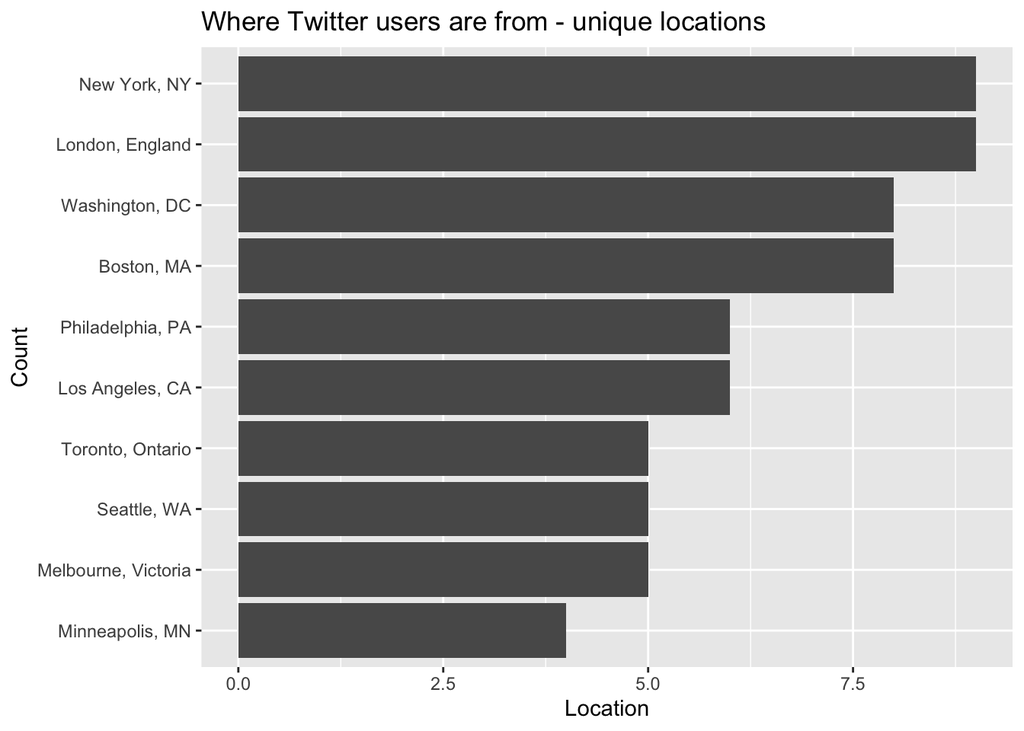

```r
users$location[users$location==""] <- NA # replace blanks with NA

df=users %>%
  count(location, sort = TRUE)  %>%               # count location by users
  mutate(location = reorder(location, n))  %>%    # sort
  slice_max( order_by=location, n = 10)   %>%     # rows with top 10 location
  drop_na()

# plot
ggplot(df, aes(x = location, y = n)) +
  geom_col() +
  coord_flip() +
      labs(x = "Count",
      y = "Location",
      title = "Where Twitter users are from - unique locations")
```

### get_timeline()

returns tweets by a specific user, up to 3200 tweets

```r
# get time line of user rstudio
gt_rstudio =  get_timeline("rstudio", n = 50)

## data frame where each observation (row) is a different tweet
gt_rstudio  %>%
  select(created_at, text)  %>%
head()
```

```
## # A tibble: 6 x 2
##   created_at          text
##   <dttm>              <chr>
## 1 2020-10-08 22:19:11 "From R Views - Fake Survival Data for the Disease Progre…
## 2 2020-10-08 19:28:14 "This week's #TidyTuesday data is about NCAA women's bask…
## 3 2020-10-08 13:04:00 "RStudio AI Blog - Introducing torch autograd\nWith {torc…
## 4 2020-10-08 09:04:01 "Q&amp;A from the recent GlaxoSmithKline webinar on Using…
## 5 2020-10-07 17:00:45 "RStudio v1.4 Preview: added support for python. \n#pydat…
## 6 2020-10-06 23:28:50 "If you need to create tables in the RTF format, the {gt}…
```

**retrieve timelines of mulitple users**

```r
gt_timelines =  get_timeline(
  c("rstudio", "tidyversetweets"),
  n = 50)

## count observations for each timeline
table(gt_timelines$screen_name)
```

```
##
##         rstudio tidyversetweets
##              50              50
```

**summary**

```r
head(gt_timelines)
```

```
## # A tibble: 6 x 90
##   user_id status_id created_at          screen_name text  source
##   <chr>   <chr>     <dttm>              <chr>       <chr> <chr>
## 1 235261… 13143295… 2020-10-08 22:19:11 rstudio     "Fro… Buffer
## 2 235261… 13142865… 2020-10-08 19:28:14 rstudio     "Thi… Twitt…
## 3 235261… 13141898… 2020-10-08 13:04:00 rstudio     "RSt… Buffer
## 4 235261… 13141294… 2020-10-08 09:04:01 rstudio     "Q&a… Buffer
## 5 235261… 13138869… 2020-10-07 17:00:45 rstudio     "RSt… Twitt…
## 6 235261… 13136222… 2020-10-06 23:28:50 rstudio     "If … Twitt…
## # … with 84 more variables: display_text_width <dbl>, reply_to_status_id <chr>,
## #   reply_to_user_id <chr>, reply_to_screen_name <chr>, is_quote <lgl>,
## #   is_retweet <lgl>, favorite_count <int>, retweet_count <int>,
## #   quote_count <int>, reply_count <int>, hashtags <list>, symbols <list>,
## #   urls_url <list>, urls_t.co <list>, urls_expanded_url <list>,
## #   media_url <list>, media_t.co <list>, media_expanded_url <list>,
## #   media_type <list>, ext_media_url <list>, ext_media_t.co <list>,
## #   ext_media_expanded_url <list>, ext_media_type <chr>,
## #   mentions_user_id <list>, mentions_screen_name <list>, lang <chr>,
## #   quoted_status_id <chr>, quoted_text <chr>, quoted_created_at <dttm>,
## #   quoted_source <chr>, quoted_favorite_count <int>,
## #   quoted_retweet_count <int>, quoted_user_id <chr>, quoted_screen_name <chr>,
## #   quoted_name <chr>, quoted_followers_count <int>,
## #   quoted_friends_count <int>, quoted_statuses_count <int>,
## #   quoted_location <chr>, quoted_description <chr>, quoted_verified <lgl>,
## #   retweet_status_id <chr>, retweet_text <chr>, retweet_created_at <dttm>,
## #   retweet_source <chr>, retweet_favorite_count <int>,
## #   retweet_retweet_count <int>, retweet_user_id <chr>,
## #   retweet_screen_name <chr>, retweet_name <chr>,
## #   retweet_followers_count <int>, retweet_friends_count <int>,
## #   retweet_statuses_count <int>, retweet_location <chr>,
## #   retweet_description <chr>, retweet_verified <lgl>, place_url <chr>,
## #   place_name <chr>, place_full_name <chr>, place_type <chr>, country <chr>,
## #   country_code <chr>, geo_coords <list>, coords_coords <list>,
## #   bbox_coords <list>, status_url <chr>, name <chr>, location <chr>,
## #   description <chr>, url <chr>, protected <lgl>, followers_count <int>,
## #   friends_count <int>, listed_count <int>, statuses_count <int>,
## #   favourites_count <int>, account_created_at <dttm>, verified <lgl>,
## #   profile_url <chr>, profile_expanded_url <chr>, account_lang <lgl>,
## #   profile_banner_url <chr>, profile_background_url <chr>,
## #   profile_image_url <chr>
```

```r
tail(gt_timelines)
```

```
## # A tibble: 6 x 90
##   user_id status_id created_at          screen_name text  source
##   <chr>   <chr>     <dttm>              <chr>       <chr> <chr>
## 1 935569… 13142619… 2020-10-08 17:50:42 tidyverset… Dot-… tidyv…
## 2 935569… 13142606… 2020-10-08 17:45:28 tidyverset… fit_… tidyv…
## 3 935569… 13142568… 2020-10-08 17:30:28 tidyverset… Plot… tidyv…
## 4 935569… 13142556… 2020-10-08 17:25:29 tidyverset… R Ho… tidyv…
## 5 935569… 13142518… 2020-10-08 17:10:36 tidyverset… geom… tidyv…
## 6 935569… 13142442… 2020-10-08 16:40:30 tidyverset… curl… tidyv…
## # … with 84 more variables: display_text_width <dbl>, reply_to_status_id <chr>,
## #   reply_to_user_id <chr>, reply_to_screen_name <chr>, is_quote <lgl>,
## #   is_retweet <lgl>, favorite_count <int>, retweet_count <int>,
## #   quote_count <int>, reply_count <int>, hashtags <list>, symbols <list>,
## #   urls_url <list>, urls_t.co <list>, urls_expanded_url <list>,
## #   media_url <list>, media_t.co <list>, media_expanded_url <list>,
## #   media_type <list>, ext_media_url <list>, ext_media_t.co <list>,
## #   ext_media_expanded_url <list>, ext_media_type <chr>,
## #   mentions_user_id <list>, mentions_screen_name <list>, lang <chr>,
## #   quoted_status_id <chr>, quoted_text <chr>, quoted_created_at <dttm>,
## #   quoted_source <chr>, quoted_favorite_count <int>,
## #   quoted_retweet_count <int>, quoted_user_id <chr>, quoted_screen_name <chr>,
## #   quoted_name <chr>, quoted_followers_count <int>,
## #   quoted_friends_count <int>, quoted_statuses_count <int>,
## #   quoted_location <chr>, quoted_description <chr>, quoted_verified <lgl>,
## #   retweet_status_id <chr>, retweet_text <chr>, retweet_created_at <dttm>,
## #   retweet_source <chr>, retweet_favorite_count <int>,
## #   retweet_retweet_count <int>, retweet_user_id <chr>,
## #   retweet_screen_name <chr>, retweet_name <chr>,
## #   retweet_followers_count <int>, retweet_friends_count <int>,
## #   retweet_statuses_count <int>, retweet_location <chr>,
## #   retweet_description <chr>, retweet_verified <lgl>, place_url <chr>,
## #   place_name <chr>, place_full_name <chr>, place_type <chr>, country <chr>,
## #   country_code <chr>, geo_coords <list>, coords_coords <list>,
## #   bbox_coords <list>, status_url <chr>, name <chr>, location <chr>,
## #   description <chr>, url <chr>, protected <lgl>, followers_count <int>,
## #   friends_count <int>, listed_count <int>, statuses_count <int>,
## #   favourites_count <int>, account_created_at <dttm>, verified <lgl>,
## #   profile_url <chr>, profile_expanded_url <chr>, account_lang <lgl>,
## #   profile_banner_url <chr>, profile_background_url <chr>,
## #   profile_image_url <chr>
```

```r
summary(gt_timelines$created_at)
```

```
##                  Min.               1st Qu.                Median
## "2020-09-10 16:25:23" "2020-09-22 19:59:33" "2020-10-08 17:18:02"
##                  Mean               3rd Qu.                  Max.
## "2020-10-01 08:31:15" "2020-10-08 20:58:34" "2020-10-09 05:31:04"
```

### ts_plot()

plot the frequency of tweets for each user over time. The ts_plot() function allows us to plot the frequency of tweets over various time intervals (e.g. “secs”, “mins”, “hours”, “days”, “weeks”, “months”, “years”)

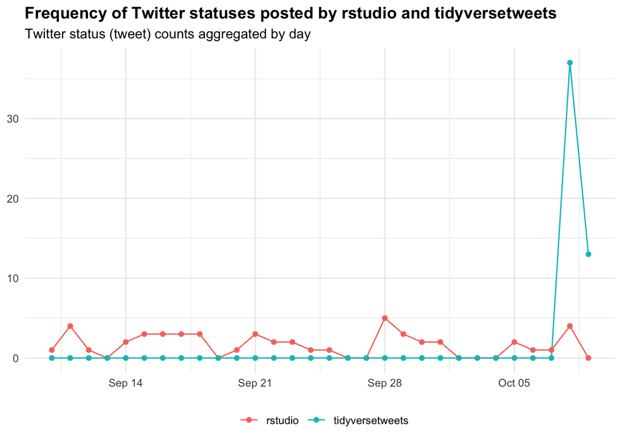

```r
gt_timelines %>%
  #filter(created_at > "2020-02-01") %>%
  group_by(screen_name) %>%
  ts_plot("days") +
  geom_point() +
  theme_minimal() +
  theme(
    legend.title = element_blank(),
    legend.position = "bottom",
    plot.title = element_text(face = "bold")) +
    labs(x = NULL, y = NULL,
      title = "Frequency of Twitter statuses posted by rstudio and tidyversetweets",
      subtitle = "Twitter status (tweet) counts aggregated by day"
  )
```

**group by screen name and plot each time series**

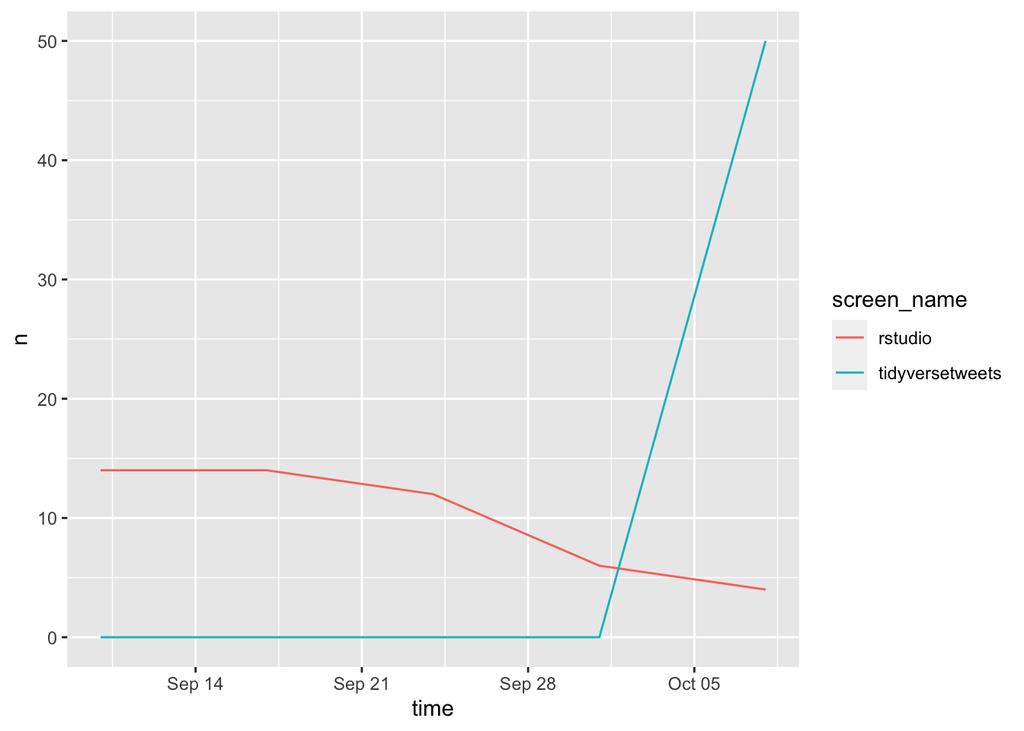

```r
# weeks
gt_timelines %>%
  group_by(screen_name) %>%
  ts_plot("weeks")
```

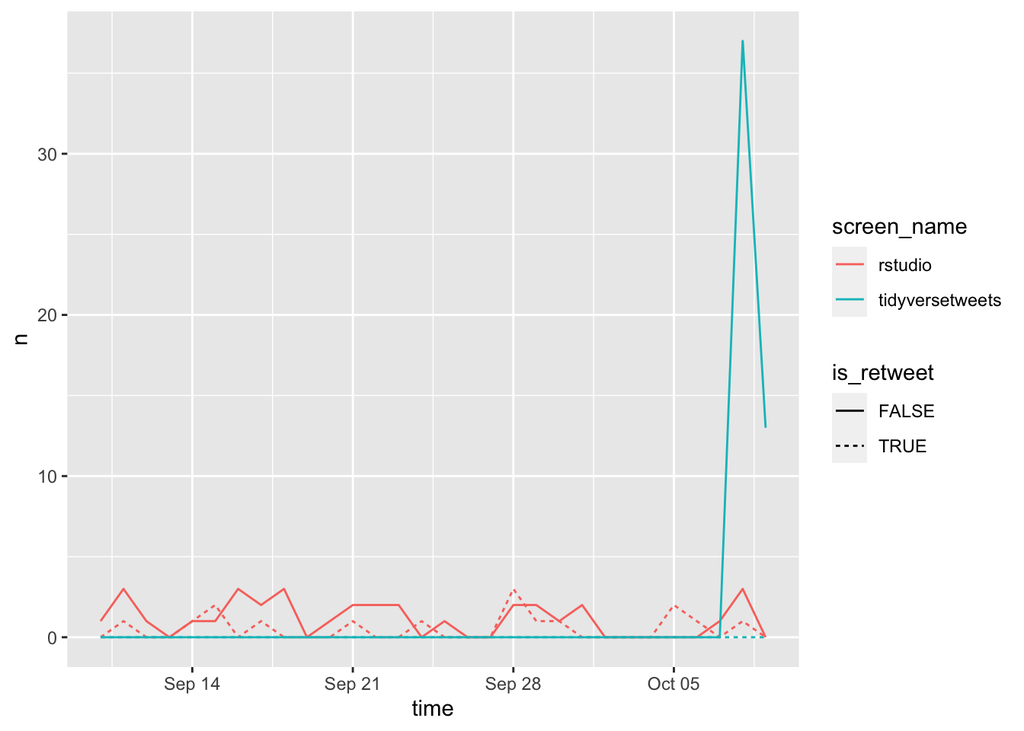

```r
# group by screen name and is_retweet
gt_timelines %>%
  group_by(screen_name, is_retweet) %>%
  ts_plot("days")
```

### lookup_users()

Get Twitter Users Data For Given Users (User IDs Or Screen Names), returns data on up to 90,000 Twitter users.

**get number of followers**

```r
lu_users <- lookup_users(c("rstudio", "tidyversetweets"))

followers = lu_users[, c('screen_name', 'followers_count')]
followers
```

```
## # A tibble: 2 x 2
##   screen_name     followers_count
##   <chr>                     <int>
## 1 rstudio                  107751
## 2 tidyversetweets            3602
```

```r
# search for tweets
rstat_tweets = search_tweets("#rstat", n=1000)

# get text that's been retweeted
retweets = rstat_tweets[, c('text', 'retweet_count')]

retweets %>%
  arrange(desc('retweet_count')) %>% # sort desc order
  unique(by = 'text') %>%            # only unique
  head(10)
```

```
## # A tibble: 10 x 2
##    text                                                            retweet_count
##    <chr>                                                                   <int>
##  1 "loon.ggplot -&gt;  INTERACTIVE ggplots\nUse l_ggplot() in pla…            48
##  2 "Here my submission for this week #TidyTuesday \"NCAA Women's …             1
##  3 "Great @StatSocAus workshop coming up in November: \"Data visu…             5
##  4 "#rWind\n#rstat https://t.co/8j573Xibbv"                                    0
##  5 "Does anyone know if you can embed a Jupyter Notebook in Black…             1
##  6 "Você sabe como instalar o R e o RStudio? Preparamos uma matér…             0
##  7 "R tanácsokat adtam a programot engedélyező részlegnek. 😎 És m…             0
##  8 "@stubyte Akkor hajrá szökés! Még a délelőtti #rstat tanfolyam…             0
##  9 "We've just updated our website to include three very interest…             6
## 10 "Loving the new extra source columns in @rstudio preview. A mu…             0
```

**filtering tweets**  
1. -filter (original tweets)  
2. -filter:retweets (excludes retweets, eg: is_retweet)  
3. -filter:quote (excludes quoted tweets, eg: is_quote)  
4. -filter:replies (excludes reply tweets, eg: reply_to_screen_name )  
5. min_faves (filters tweets by min number of favorite)  
6. min_retweets (filter tweets by min number of retweets)

more info: https://developer.twitter.com/en/docs/twitter-api/v1/rules-and-filtering/overview/standard-operators

```r
da_tweets = search_tweets("data analysis -filter:retweets",  # exclude retweets
                          n=200)

print('count of retweets')
```

```
## [1] "count of retweets"
```

```r
da_tweets %>%
  dplyr::count(is_retweet)
```

```
## # A tibble: 1 x 2
##   is_retweet     n
##   <lgl>      <int>
## 1 FALSE        200
```

```r
print('count of quoted tweets')
```

```
## [1] "count of quoted tweets"
```

```r
da_tweets %>%
 dplyr::count(is_quote)
```

```
## # A tibble: 2 x 2
##   is_quote     n
##   <lgl>    <int>
## 1 FALSE      196
## 2 TRUE         4
```

```r
print('count of replies tweets')
```

```
## [1] "count of replies tweets"
```

```r
da_tweets %>%
  dplyr::count(da_tweets$reply_to_screen_name)
```

```
## # A tibble: 76 x 2
##    `da_tweets$reply_to_screen_name`     n
##    <chr>                            <int>
##  1 abcnews                              1
##  2 ACMcCosker                           1
##  3 alvlebedev                           1
##  4 AmereihnCarolyn                      1
##  5 armorblox                            1
##  6 bdavidsonlamb                        1
##  7 BefittingFacts                       1
##  8 bennedose                            1
##  9 Beyondlostcause                      1
## 10 BlackPRWire                          1
## # … with 66 more rows
```

```r
# filtered by min_faves and min_retweets
filtered_tweets = search_tweets("data analysis min_faves:50 AND min_retweets:25", n=200)

print('count of favs and retweets')
```

```
## [1] "count of favs and retweets"
```

```r
filtered_tweets %>%
  select(retweet_count, favorite_count) %>%
  head()
```

```
## # A tibble: 6 x 2
##   retweet_count favorite_count
##           <int>          <int>
## 1           714           2042
## 2           933           2704
## 3            61             76
## 4            34             86
## 5           226            108
## 6            68            327
```

### get_trends()

Get Twitter trends data. Trends are keywords, events, topics that are currently popular

### trends_available()

Retrieve available trends

```r
trends <- trends_available()
trends
```

```
## # A tibble: 467 x 8
##    name    url             parentid country   woeid countryCode  code place_type
##    <chr>   <chr>              <int> <chr>     <int> <chr>       <int> <chr>
##  1 Worldw… http://where.y…        0 ""            1 <NA>           19 Supername
##  2 Winnip… http://where.y… 23424775 "Canada"   2972 CA              7 Town
##  3 Ottawa  http://where.y… 23424775 "Canada"   3369 CA              7 Town
##  4 Quebec  http://where.y… 23424775 "Canada"   3444 CA              7 Town
##  5 Montre… http://where.y… 23424775 "Canada"   3534 CA              7 Town
##  6 Toronto http://where.y… 23424775 "Canada"   4118 CA              7 Town
##  7 Edmont… http://where.y… 23424775 "Canada"   8676 CA              7 Town
##  8 Calgary http://where.y… 23424775 "Canada"   8775 CA              7 Town
##  9 Vancou… http://where.y… 23424775 "Canada"   9807 CA              7 Town
## 10 Birmin… http://where.y… 23424975 "United … 12723 GB              7 Town
## # … with 457 more rows
```

**US trends**

```r
us_trends <- get_trends('United States')
head(us_trends)
```

```
## # A tibble: 6 x 9
##   trend url   promoted_content query tweet_volume place  woeid
##   <chr> <chr> <lgl>            <chr>        <int> <chr>  <int>
## 1 Brady http… NA               Brady       129028 Unit… 2.34e7
## 2 Bears http… NA               Bears       124329 Unit… 2.34e7
## 3 Nick… http… NA               %22N…        29576 Unit… 2.34e7
## 4 #Dod… http… NA               %23D…        25098 Unit… 2.34e7
## 5 Bucs  http… NA               Bucs         38541 Unit… 2.34e7
## 6 Padr… http… NA               Padr…       111389 Unit… 2.34e7
## # … with 2 more variables: as_of <dttm>, created_at <dttm>
```

**SF trends**

```r
sf_trends <- get_trends('San Francisco')
head(sf_trends)
```

```
## # A tibble: 6 x 9
##   trend url   promoted_content query tweet_volume place  woeid
##   <chr> <chr> <lgl>            <chr>        <int> <chr>  <int>
## 1 Brady http… NA               Brady       129028 San … 2.49e6
## 2 Mich… http… NA               Mich…       955670 San … 2.49e6
## 3 #Dod… http… NA               %23D…        25098 San … 2.49e6
## 4 Padr… http… NA               Padr…       111389 San … 2.49e6
## 5 #NLCS http… NA               %23N…           NA San … 2.49e6
## 6 #Fri… http… NA               %23F…           NA San … 2.49e6
## # … with 2 more variables: as_of <dttm>, created_at <dttm>
```

**most tweeted trends**

‘tweet_volume’ is a count of tweets on a trending topic, available for some trends only

```r
sf_trends %>%
  group_by(trend) %>%
  summarise(avg_tweet_vol = mean(tweet_volume)) %>%
  arrange(desc(avg_tweet_vol))
```

```
## # A tibble: 20 x 2
##    trend          avg_tweet_vol
##    <chr>                  <dbl>
##  1 Michigan              955670
##  2 Brady                 129028
##  3 Bears                 124329
##  4 Padres                111389
##  5 Hannity                99534
##  6 ENGENE                 95905
##  7 Braves                 74155
##  8 Yelp                   59094
##  9 Bucs                   38553
## 10 Nick Foles             29576
## 11 #Dodgers               25098
## 12 Khalil Mack            21682
## 13 #FriarFaithful            NA
## 14 #LADvsSD                  NA
## 15 #LATogether               NA
## 16 #NLCS                     NA
## 17 Gronk                     NA
## 18 Lamet                     NA
## 19 TB12                      NA
## 20 Urias                     NA
```